# R Data Wrangling and Manipulation: Part 2

## The big picture

Consider the data below. Both data sets display information on heart rate observed in individuals across three different time periods. But the data are organized differently in each table. Which one of these do you think is the *tidy* format?

```r
wide <- data.frame(
  name = c("Wilbur", "Petunia", "Gregory"),
  time1 = c(67, 80, 64),
  time2 = c(56, 90, 50),
  time3 = c(70, 67, 101)
)
wide
```

```
##      name time1 time2 time3
## 1  Wilbur    67    56    70
## 2 Petunia    80    90    67
## 3 Gregory    64    50   101
```

```r
long <- data.frame(
  name = c("Wilbur", "Petunia", "Gregory", "Wilbur", "Petunia", "Gregory", "Wilbur", "Petunia", "Gregory"),
  time = c(1, 1, 1, 2, 2, 2, 3, 3, 3),
  heartrate = c(67, 80, 64, 56, 90, 50, 70, 67, 10)
)
long
```

```
##      name time heartrate
## 1  Wilbur    1        67
## 2 Petunia    1        80
## 3 Gregory    1        64
## 4  Wilbur    2        56
## 5 Petunia    2        90
## 6 Gregory    2        50
## 7  Wilbur    3        70
## 8 Petunia    3        67
## 9 Gregory    3        10
```

For the “wide” format, each row is often a site/subject/patient, and you have multiple observation variables containing the same type of data. These can be repeated observations over time or multiple variables (or a mix of both). In the above case, we had the same kind of data (heart rate) entered across three different columns, corresponding to three different time periods. The key here is that these underlying characteristics are shared by a discrete entity.

We often refer to these two opposite structures as “long” vs. “wide” formats. In the “long” format, you usually have 1 column for the observed variable(s), and the other columns are ID variables. We do this most often when the columns are not names of variables, but instead values of variables. Our next example provides the conceptual underpinnings of this approach.

## An Example Workflow

Here’s an example of a data wrangling workflow that starts from reading in a dataset and then makes a dataset suitable for a descriptive analysis. This example contains an example of every verb we will talk about in this workshop.

Suppose we have a dataset of individuals’ occupations from different US states. In the data folder for this workshop repository, a dataset called “jobs” matches this description. We can read it in with `read_csv(),` which is available from the tidyverse. `read_csv` works exactly like `read.csv` but is much quicker.

The `here` function is a way to create file paths relative to the top-level directory.

For a descriptive analysis, we’d like to know the average age for individuals who are and are not in agriculture for states within each state on the West Coast. To accomplish this task, we will need to:

- filter our list of states
- group by each state, create a variable denoting whether the individual works in agriculture or not, and
- summarize the average age of individuals who do and do not work in agriculture.

Finally, we’d like to arrange the states in reverse alphabetical order.

What follows is an example of the workflow just described in the spirit of [teaching the whole game](https://www.gse.harvard.edu/news/uk/09/01/education-bat-seven-principles-educators)

```r
## Data import
jobs <- read_csv("data/jobs.csv", show_col_types = FALSE)
```

Let’s look at the first six rows of this dataset

```r
head(jobs)
```

```
## # A tibble: 6 × 10
##     Age State         Income Education Employment Marital Smokes Political Name
##   <dbl> <chr>          <dbl> <chr>     <chr>      <chr>   <lgl>  <chr>     <chr>
## 1    19 Virginia      1.24e5 Some Col… Retired    Divorc… FALSE  Democrat  Alej…
## 2    20 New York      2.41e4 Bachelor… Full Time  Divorc… FALSE  Democrat  Lyns…
## 3    20 Mississippi   4.47e4 Bachelor… Retired    Married FALSE  Democrat  Moni…
## 4    60 California    3.58e4 Regular … Full Time  Married FALSE  Republic… Tine…
## 5    33 North Caroli… 7.99e4 Bachelor… Retired    Widowed FALSE  Republic… Iveth
## 6    25 North Caroli… 4.84e4 Associat… Full Time  Widowed TRUE   Republic… Ryus…
## # ℹ 1 more variable: Occupation <chr>
```

Within the tidyverse, there’s also a nice function in the tidyverse called `glimpse()` which makes it possible to see every column in the data frame.

```r
glimpse(jobs)
```

```
## Rows: 1,000
## Columns: 10
## $ Age        <dbl> 19, 20, 20, 60, 33, 25, 24, 86, 82, 64, 23, 80, 65, 33, 51,…
## $ State      <chr> "Virginia", "New York", "Mississippi", "California", "North…
## $ Income     <dbl> 124372.99, 24104.03, 44743.06, 35795.61, 79870.98, 48383.12…
## $ Education  <chr> "Some College, 1 or More Years, No Degree", "Bachelor's Deg…
## $ Employment <chr> "Retired", "Full Time", "Retired", "Full Time", "Retired", …
## $ Marital    <chr> "Divorced", "Divorced", "Married", "Married", "Widowed", "W…
## $ Smokes     <lgl> FALSE, FALSE, FALSE, FALSE, FALSE, TRUE, TRUE, FALSE, FALSE…
## $ Political  <chr> "Democrat", "Democrat", "Democrat", "Republican", "Republic…
## $ Name       <chr> "Alejandra", "Lynsay", "Monise", "Tineshia", "Iveth", "Ryus…
## $ Occupation <chr> "Lawyer", "Data Scientist", "Lawyer", "Construction", "Unem…
```

```r
## Workflow

  ## Start with the jobs data frame
jobs |>
  ## Select and keep only three columns of interest
  select(State, Occupation, Age) |>
  ## Subset down to just the observations that match 4 states
  filter(State %in% c("Alaska","California", "Oregon", "Washington")) |>
  ## create a dummy variable about whether an occupation is in agriculture
  mutate(in_ag = if_else(Occupation == "Farmer", "Yes", "No")) |>
  ## group the observations by state and then the created dummy
  group_by(State, in_ag) |>
  ## create a new data frame with a summary of the age variable
  ## for each grouping
  summarise(average_age = mean(Age), .groups = "drop_last") |>
  ## Sort the rows in reverse order by state
  arrange(desc(State))
```

```
## # A tibble: 8 × 3
## # Groups:   State [4]
##   State      in_ag average_age
##   <chr>      <chr>       <dbl>
## 1 Washington No           55
## 2 Washington Yes          64.5
## 3 Oregon     No           49.3
## 4 Oregon     Yes          58
## 5 California No           53.8
## 6 California Yes          53.6
## 7 Alaska     No           64
## 8 Alaska     Yes          77
```

```r
## We can also save the output of our workflow to a new data frame object
wc_lifeExp <- jobs |>
  select(State, Occupation, Age) |>
  filter(State %in% c("Alaska","California", "Oregon", "Washington")) |>
  mutate(in_ag = if_else(Occupation == "Farmer", "Yes", "No")) |>
  group_by(State, in_ag) |>
  summarise(average_age = mean(Age), .groups = "drop_last") |>
  arrange(desc(State))
```

The way to think of the pipe, the symbol at the end of each of these lines that is `|>`, is that it takes what is on the left side and makes it the first argument of the right side.

The tidyverse is built around pipes because the first argument of every function in the tidyverse is a data frame, which means that the tidyverse all follows the same structure. When doing data tasks, having the same structure turns out to be very useful because it is easy to reason about what a function will do and what it needs.

## What are we doing in Part 2?

Part 2 focuses on extending the base skills learned in Part 1. We are still interested in turning messy data into tidy data. This section will cover several common problems with messy data sets [Wickham 2014](https://vita.had.co.nz/papers/tidy-data.html). These are

1. Column headers that are values, not variable names.
2. Overloading variables into a single column.
3. Storing variables in both rows and columns.
4. Storing multiple types of units in the same data frame.
5. Storing a single type in multiple tables.

Within our discussion of (4) and (5), we will cover two table verbs in the tidyverse. In real data analysis projects, we will rarely have one data frame to do all of our analysis.

## Column headers that are values, not variable names

This messy data type is common in survey data, especially if you’re working off of someone else’s crosstabs.

Imagine you’re researching the housing crisis in California. You come across a dataset from Berkeley’s [Institute for Governmental Studies](https://igs.berkeley.edu/research/berkeley-igs-poll) that has information on preferences for moving broken down by age group.

Read in the dataset called `cal_housing.csv` in the data folder.

```r
cal_housing <- read_csv("data/cal_housing.csv", show_col_types = FALSE)
View(cal_housing)
```

Our end goal is to make a visualization showing consideration of moving by age group. `ggplot2` presumes that we have tidy data to work. We need to *pivot* the non-variable columns into a two-column key-value pair to make our graph. This pivot operation will turn the age columns (e.g. `18-29`) into an age column where the age 18-29 is one of the possible values.

Recall from Part 1 that the appropriate tidyverse function for this operation is `pivot_longer()`.

```r
cal_housing_long <- cal_housing |>
  pivot_longer(-leaving,
               names_to = "age",
               values_to = "percent_agreement")
head(cal_housing_long)
```

```
## # A tibble: 6 × 3
##   leaving age   percent_agreement
##   <chr>   <chr>             <dbl>
## 1 Serious 18-29                23
## 2 Serious 30-39                25
## 3 Serious 40-49                28
## 4 Serious 50-64                26
## 5 Serious 65+                  17
## 6 Some    18-29                29
```

From here, we could make a bar graph showing response by age groups.

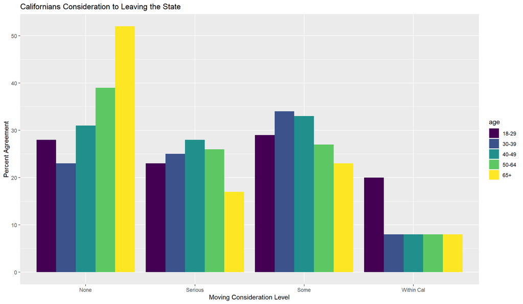

```r
cal_housing_long |>
  ggplot(aes(x = leaving, y = percent_agreement, fill=age))+
  geom_col(position = 'dodge')+
  xlab("Moving Consideration Level")+
  ylab("Percent Agreement")+
  # colorblind friendly palette
  scale_fill_viridis_d()+
  ggtitle("Californians Consideration to Leaving the State")
```

## Challenge 7

The IGS poll also contains a question broken down by region (`cal_region.csv`). Build a pipeline that reads and tidies the data. For extra practice, make a similar graph to display the results.

```r
## Fill in your solution here
cr <- read_csv("data/cal_region.csv", show_col_types = FALSE)
```

## Overloading variables into a single column

Sometimes we have a dataset where our key column is a combination of multiple variables. This is a relatively standard raw data format in research projects that collect data at multiple sub-level sites over time.

To illustrate the problem, consider the following dataset inspired by bird watchers.

```r
birds <- read_csv("data/birds.csv", show_col_types = FALSE)
View(birds)
```

We see that we have columns that combine two different variables, the species of bird (“eagle” and “warbler”) and the location of a sighting (“nest” and “air”). When encountering this situation, we use a two-step process.

1. Pivot to gather the non-variable columns
2. Separate the overloaded column.

In a workflow, it looks like this.

```r
good_birds <- birds |>
  pivot_longer(!c(county,year),
               names_to = "sight",
               values_to = "n",
               values_drop_na = TRUE) |>
  separate(sight, c("type", "location"), sep = "(?=[A-Z])")
head(good_birds)
```

```
## # A tibble: 6 × 5
##   county       year type    location     n
##   <chr>       <dbl> <chr>   <chr>    <dbl>
## 1 Alameda      2020 eagle   Nest         0
## 2 Alameda      2020 eagle   Air          2
## 3 Alameda      2020 warbler Nest         4
## 4 Alameda      2020 warbler Air         30
## 5 Contra Cost  2020 eagle   Nest         0
## 6 Contra Cost  2020 eagle   Air          5
```

Here we first pivoted the data frame to consolidate values into two variables: “sight” and “n” where the latter represents the number of sightings. Next, we separated the sight column into a type variable and a location. This makes the data tidy because each bird is a subset of type and “Nest” and “Air” are both types of locations.

The workflow above used a [regular expression](https://stringr.tidyverse.org/articles/regular-expressions.html) to split and keep the capital letter. Regular expressions are, in general, beyond the scope of this course. A great resource to practice regular expressions is [regex101.com](https://regex101.com/)

Another way to separate is by position. Separating by position on datasets with a standard format can be helpful. Let’s look at what happens when we separate by the 1st position.

```r
sep_ex <- birds |>
  pivot_longer(!c(county,year),
               names_to = "sight",
               values_to = "n",
               values_drop_na = TRUE)|>
  separate(sight, c("type", "location"),sep = 1)
head(sep_ex)
```

```
## # A tibble: 6 × 5
##   county       year type  location       n
##   <chr>       <dbl> <chr> <chr>      <dbl>
## 1 Alameda      2020 e     agleNest       0
## 2 Alameda      2020 e     agleAir        2
## 3 Alameda      2020 w     arblerNest     4
## 4 Alameda      2020 w     arblerAir     30
## 5 Contra Cost  2020 e     agleNest       0
## 6 Contra Cost  2020 e     agleAir        5
```

We can fix our incorrect columns with `mutate()`. The following is a brute force method to do this, but as you continue in your data wrangling journey, We strongly encourage you to seek out more efficient ways of solving this problem.

```r
sep_ex_fixed <- sep_ex |>
  mutate(type = if_else(type == "e", "Eagle", "Warbler"),
         location = case_when(
           location == "agleNest"~"Nest",
           location == "agleAir"~"Air",
           location == "arblerNest"~"Nest",
           location == "arblerAir"~"Air"
         ))
head(sep_ex_fixed)
```

```
## # A tibble: 6 × 5
##   county       year type    location     n
##   <chr>       <dbl> <chr>   <chr>    <dbl>
## 1 Alameda      2020 Eagle   Nest         0
## 2 Alameda      2020 Eagle   Air          2
## 3 Alameda      2020 Warbler Nest         4
## 4 Alameda      2020 Warbler Air         30
## 5 Contra Cost  2020 Eagle   Nest         0
## 6 Contra Cost  2020 Eagle   Air          5
```

## Challenge 8

Edit the workflow presented above to split on the fifth character. Use `mutate` to replace the incorrect values with corrected and capitalized names. You can follow the brute force way shown above, or potentially investigate [str_replace_all()](https://stringr.tidyverse.org/reference/str_replace.html), [str_detect()](https://stringr.tidyverse.org/reference/str_detect.html), and [str_to_title()](https://stringr.tidyverse.org/reference/case.html) for options with string matching.

## Storing variables in both rows and columns

Far less often, though far more frustratingly, variables can be stored in both rows and columns. Such datasets are surprisingly frequent in climate, geological, and health research. As a representative example of this problem, consider the hypothetical surveillance testing schedule for an athlete at Berkeley during the season. The data is called `testing.csv`

```r
testing <- read_csv("data/testing.csv", show_col_types = FALSE)
View(testing)
```

Note that we have variables in individual columns and a variable spread across multiple columns (the day variable), and variables spread across rows (the test variable is composed of two separate tests).

In such a situation, we make use of both `pivot_longer()` and `pivot_wider()`. Our design pattern is to gather any variables spread across columns and then widen any columns with multiple variables within.

```r
## Step 1
step_1 <- testing |>
  pivot_longer(
    # an alternative method for selecting columns
    d1:d7,
    names_to = "day",
    values_to = "result",
    values_drop_na = TRUE
  )|>
  # remove the d from day and trim any white space
  # VERY USEFUL to avoid merge problems
  mutate(day = as.numeric(str_replace_all(day,"d", "")%>%trimws()))
head(step_1)
```

```
## # A tibble: 6 × 6
##   patient_id  year  week test    day result
##   <chr>      <dbl> <dbl> <chr> <dbl>  <dbl>
## 1 X12         2021     1 pcr       1      0
## 2 X12         2021     1 pcr       2      0
## 3 X12         2021     1 pcr       3      0
## 4 X12         2021     1 pcr       4      0
## 5 X12         2021     1 pcr       5      0
## 6 X12         2021     1 pcr       6      0
```

We now have a dataset close to a tidy dataset, except we have a problem. Two tests are being performed each day, and we only have one variable—time for step 2.

```r
step_2 <- step_1 |>
  pivot_wider(
    names_from = test,
    values_from = result
  )
head(step_2)
```

```
## # A tibble: 6 × 6
##   patient_id  year  week   day   pcr rapid
##   <chr>      <dbl> <dbl> <dbl> <dbl> <dbl>
## 1 X12         2021     1     1     0     0
## 2 X12         2021     1     2     0     0
## 3 X12         2021     1     3     0     0
## 4 X12         2021     1     4     0     0
## 5 X12         2021     1     5     0     0
## 6 X12         2021     1     6     0     0
```

Now we have one variable in each column, and each row represents a single day of testing.

A trick that we can sometimes use occurs if we have data that looks like the following:

```r
underscore <- read_csv("data/underscore.csv", show_col_types = FALSE)
View(underscore)
```

This is wide data that we would like to transform to long data, but if we do a usual `pivot_longer()`, we will end up with the problem we want to avoid in this section.

```r
# Bad
underscore |>
  pivot_longer(cols = -id,
               names_to = "observation",
               values_to = "value")
```

```
## # A tibble: 12 × 3
##    id    observation value
##    <chr> <chr>       <dbl>
##  1 A     val1_year    2020
##  2 A     val1_result     1
##  3 A     val2_year    2021
##  4 A     val2_result     1
##  5 B     val1_year    2020
##  6 B     val1_result     1
##  7 B     val2_year    2021
##  8 B     val2_result     1
##  9 C     val1_year    2020
## 10 C     val1_result     0
## 11 C     val2_year    2021
## 12 C     val2_result     1
```

Here the dates and the results are merged into one value. However, in situations with a standard naming structure, we can use some of the built-in arguments of `pivot_longer()`.

```r
underscore |>
  pivot_longer(cols = -id,
               # special term indicates that column is split based
               # on character in name
               names_to = c("observation", ".value"),
               names_sep = "_",
               values_to = "value")
```

```
## # A tibble: 6 × 4
##   id    observation  year result
##   <chr> <chr>       <dbl>  <dbl>
## 1 A     val1         2020      1
## 2 A     val2         2021      1
## 3 B     val1         2020      1
## 4 B     val2         2021      1
## 5 C     val1         2020      0
## 6 C     val2         2021      1
```

Once again, we get a tidy data frame that we can work with for future analyses.

## Joining information from multiple datasets

A fundamental principle of tidy data, and data wrangling in general, is to keep “like for like” in the same table. Each type of observation should be stored in its own table. For example, database of song rankings by week over time (see `tidyr::billboard`) needs to be broken into two pieces, a dataset that stores unique artist-song pairs, and a rankings dataset which gives the ranking of each song each week. This principle is closely related to database normalization, and is important to prevent inconsistencies that can arise through mixing observation types (Wickham 2014).

Datasets often violate this guideline when they have values collected at multiple levels on different types of observations.

First, let’s briefly review the two table verbs available in `dplyr`. The package breaks them up into three families.

1. Mutating joins add new variables to one table from matching rows in another.

```r
df1 <- tibble(a = c(2,4), b = c(4,6))
df2 <- tibble(a = c(3,2), x = 10, y = "b")
df3 <- tibble(other = c(2,2), yet_other = c(4,6),
              x = 10, y = "b")
## inner_join() includes only observations that match both df1 and df2
df1 |>
  inner_join(df2)
```

```
## # A tibble: 1 × 4
##       a     b     x y
##   <dbl> <dbl> <dbl> <chr>
## 1     2     4    10 b
```

```r
## left_join() includes all observations in df1 regardless if they match or not. By far the most common join
df1 |>
  left_join(df2)
```

```
## # A tibble: 2 × 4
##       a     b     x y
##   <dbl> <dbl> <dbl> <chr>
## 1     2     4    10 b
## 2     4     6    NA <NA>
```

We can also specify the column(s) we want to specify common variables to join.

```r
## this will lead to an error
df1 |>
  left_join(df3)
```

```r
## These will return values
df1 |>
  left_join(df3, by = c("a"= "other"))
```

```
## # A tibble: 3 × 5
##       a     b yet_other     x y
##   <dbl> <dbl>     <dbl> <dbl> <chr>
## 1     2     4         4    10 b
## 2     2     4         6    10 b
## 3     4     6        NA    NA <NA>
```

```r
df1 |>
  left_join(df3, by = c("a" = "other",
                        "b"="yet_other"))
```

```
## # A tibble: 2 × 4
##       a     b     x y
##   <dbl> <dbl> <dbl> <chr>
## 1     2     4    10 b
## 2     4     6    NA <NA>
```

```r
## right_join() includes all observations in df2. Equivalent to left_join() but with different ordered columns
df1 |>
  right_join(df2)
```

```
## # A tibble: 2 × 4
##       a     b     x y
##   <dbl> <dbl> <dbl> <chr>
## 1     2     4    10 b
## 2     3    NA    10 b
```

```r
## full_join() includes all observations from both df1 and df2
df1 |>
  full_join(df2)
```

```
## # A tibble: 3 × 4
##       a     b     x y
##   <dbl> <dbl> <dbl> <chr>
## 1     2     4    10 b
## 2     4     6    NA <NA>
## 3     3    NA    10 b
```

Application: Making a balanced panel dataset

A common type of dataset for analysis in many social science fields is [panel data](https://en.wikipedia.org/wiki/Panel_data). In a balanced panel, all units are observed each time unit. For example, if there were N units and T periods, the total number of rows would be NxT.

The dataset for this exercise is `obs.csv`

```r
obs <- read_csv("data/obs.csv", show_col_types = FALSE)
View(obs)
```

We now take advantage of a useful function from `tidyr` called `expand()` along with functions that we have seen before. `expand()` generates all combinations of variables found in a dataset. We can pair it with `nesting()`, which only finds combinations already present in the data, or `crossing()`, which de-duplicates and sorts inputs.

```r
panel <- obs |>
  # the nesting function finds only the combinations that
  # occur in the data
  expand(year,nesting(id)) |>
  left_join(obs) |>
  # move the id column to the front of the data frame
  # visually nice
  relocate(id) |>
  arrange(id)
glimpse(panel)
```

```
## Rows: 33
## Columns: 3
## $ id      <chr> "A", "A", "A", "A", "A", "A", "A", "A", "A", "A", "A", "B", "B…
## $ year    <dbl> 2010, 2011, 2012, 2013, 2014, 2015, 2016, 2017, 2018, 2019, 20…
## $ lifeExp <dbl> 76, 77, 77, 78, 79, 79, 82, 85, 85, 85, 85, 72, NA, NA, NA, NA…
```

2. Filtering joins match observations and are most useful for diagnosing mismatches in a join.

```r
## semi_join()
df1 |>
  semi_join(df2)
```

```
## # A tibble: 1 × 2
##       a     b
##   <dbl> <dbl>
## 1     2     4
```

```r
## anti_join()
df1 |>
  anti_join(df2)
```

```
## # A tibble: 1 × 2
##       a     b
##   <dbl> <dbl>
## 1     4     6
```

3. Set operations treat observations like sets and expect datasets to have the same variables. We are not covering these in this workshop. For more information, consult the `dplyr` [manual page](https://dplyr.tidyverse.org/reference/setops.html).

## Challenge 9: Bulk Recoding Values with a lookup table

Suppose you have a survey that asked three questions (var1,var2, var3) to fifteen subjects.

```r
set.seed(1234)
survey_raw_data <-tibble(
  ID = LETTERS[1:15],
  var1 = sample(1:15, replace = F),
  var2 = sample(16:30, replace = F),
  var3 = sample(31:45, replace = F)
)
glimpse(survey_raw_data)
```

```
## Rows: 15
## Columns: 4
## $ ID   <chr> "A", "B", "C", "D", "E", "F", "G", "H", "I", "J", "K", "L", "M", …
## $ var1 <int> 12, 10, 6, 5, 9, 15, 13, 8, 4, 2, 11, 14, 3, 7, 1
## $ var2 <int> 29, 30, 23, 19, 27, 20, 28, 26, 18, 24, 25, 17, 16, 21, 22
## $ var3 <int> 45, 38, 41, 34, 33, 37, 39, 43, 36, 42, 32, 44, 35, 31, 40
```

Survey data is likely to contain errors. Perhaps the enumerators filled in a question incorrectly. Maybe you have a particular value for missing data. As a subject matter expert, you realize that several fixes need to be made globally. You put them into a data frame.

```r
fixes <- tibble(
  ID = c("O", "G", "D", "D"),
  original_var = c("var1", "var2", "var2", "var3"),
  original_response = as.integer(c(1, 28, 19, 34)),
  correct_response = as.integer(c(1000, 2800, 1900, 3400))
)
glimpse(fixes)
```

```
## Rows: 4
## Columns: 4
## $ ID                <chr> "O", "G", "D", "D"
## $ original_var      <chr> "var1", "var2", "var2", "var3"
## $ original_response <int> 1, 28, 19, 34
## $ correct_response  <int> 1000, 2800, 1900, 3400
```

Here we have a problem of updating several variables based on a set of potentially different conditions. Each variable needs to be updated based on the ID, but we do not need to update every variable/ID combination.

Build a workflow that converts the incorrect answers to correct answers. A solution to this problem makes use of `left_join()`, `mutate()`, `select()`, and both `pivot_longer()` and `pivot_wider()`

## Binding Together Data Frames

If you know that you have data frames that share columns or rows, you can efficiently turn them into a single data frame with `bind_rows()` or `bind_cols()`. The function that you use depends on the structure of your problem.

```r
## An Example
obs1 <- obs |>
  filter(id == "A")

obs2 <- obs |>
  filter(id == "B")

bind_rows(list(obs1, obs2))
```

```
## # A tibble: 14 × 3
##    id     year lifeExp
##    <chr> <dbl>   <dbl>
##  1 A      2010      76
##  2 A      2011      77
##  3 A      2012      77
##  4 A      2013      78
##  5 A      2014      79
##  6 A      2015      79
##  7 A      2016      82
##  8 A      2017      85
##  9 A      2018      85
## 10 A      2019      85
## 11 A      2020      85
## 12 B      2010      72
## 13 B      2015      74
## 14 B      2020      75
```

## Storing a single type in multiple tables

It is common to find data values about a single observational unit spread out over multiple tables or files. Files are often split by another variable. For example, a set of medical records may be divided by patients. Voting records may be separated by counties or states. Economic data may be separated by economic sector. From a wrangling perspective, as long as there is a consistent format to these records, we can follow a three-step pattern:

1. Read the files into a list of data frames
2. For each data frame, add a new column that records the original filename
3. Combine all the data frames into a single data frame.

This pattern is so common that it is now built into the `readr` package.

```r
# Get appropriate files.
# Here we assume that we have .csv files, but any
# support file type will work
files <- fs::dir_ls(path = "/PATH", glob = "*pattern*csv")

## for example, maybe we have voting records by county
files <- fs::dir_ls(path = "/PATH", glob = "*county*csv")
df <- read_csv(files, id = "path", show_col_types = FALSE)

## or in one pipeline
df <- fs::dir_ls(path = "/PATH", glob = "*pattern*csv") |>
  read_csv(id = "path", show_col_types = FALSE)
```

## Challenge 10: Combining files with `readr`

In the data folder, there is a sub-directory called penguins. This directory splits up the data from the `palmerpenguins` package into three data frames split by species. Turn these three files into one data frame.